# Time Series with Shaded Regions, plot GDP with recessions

[Fan Wang](https://fanwangecon.github.io/)

2023-12-24

# 1 Time-series Plots with Shaded Areas

> Go to the [**RMD**](https://github.com/FanWangEcon//R4Econ/blob/master/tabgraph/ggline//fs_ggline_recession.Rmd), [**R**](https://github.com/FanWangEcon//R4Econ/blob/master/tabgraph/ggline//htmlpdfr/fs_ggline_recession.R), [**PDF**](https://github.com/FanWangEcon//R4Econ/blob/master/tabgraph/ggline//htmlpdfr/fs_ggline_recession.pdf), or [**HTML**](https://fanwangecon.github.io//R4Econ/tabgraph/ggline//htmlpdfr/fs_ggline_recession.html) version of this file. Go back to [fan](http://fanwangecon.github.io/)’s [REconTools](https://fanwangecon.github.io/REconTools/) research support package, [R4Econ](https://fanwangecon.github.io/R4Econ/) examples page, [PkgTestR](https://fanwangecon.github.io/PkgTestR/) packaging guide, or [Stat4Econ](https://fanwangecon.github.io/Stat4Econ/) course page.

## 1.1 Single Time-series with Single Type of Shade

One of the assumption will be that we have data at discrete intervals, and the shaded areas will take mid-points.

First, we repeat the basic time-series data construction found in [R4Econ.fs_ggline_basic](https://fanwangecon.github.io/R4Econ/tabgraph/ggline/htmlpdfr/fs_ggline_basic.html).

```r
# Load data, and treat index as "year", pretend data to be country-data
df_gdp <- as_tibble(attitude) %>%
    rowid_to_column(var = "year") %>%
    select(year, rating, complaints, learning) %>%
    rename(stats_usa = rating, stats_uk = learning) %>%
    pivot_longer(
        cols = starts_with("stats_"),
        names_to = c("country"),
        names_pattern = paste0("stats_(.*)"),
        values_to = "gdp"
    )

# Print
kable(df_gdp[1:10, ]) %>% kable_styling_fc()
```

| year | complaints | country | gdp |
| --- | --- | --- | --- |
| 1 | 51 | usa | 43 |
| 1 | 51 | uk | 39 |
| 2 | 64 | usa | 63 |
| 2 | 64 | uk | 54 |
| 3 | 70 | usa | 71 |
| 3 | 70 | uk | 69 |
| 4 | 63 | usa | 61 |
| 4 | 63 | uk | 47 |
| 5 | 78 | usa | 81 |
| 5 | 78 | uk | 66 |

Second, we select a subset of period to shade. We generate a random subset of non-overlapping consecutive numbers following what is outlined in [R4Econ.fs_ary_generate](https://fanwangecon.github.io/R4Econ/amto/array/htmlpdfr/fs_ary_generate.html).

```r
# Number of random starting index
it_start_idx <- min(df_gdp$year)
it_end_idx <- max(df_gdp$year)
it_startdraws_max <- 6
it_duramax <- 2
it_backward_win <- 0.3
it_forward_win <- 0.3

# Random seed
set.seed(1234)
# Draw random index between min and max
ar_it_start_idx <- sort(sample(
    seq(it_start_idx, it_end_idx),
    it_startdraws_max,
    replace = FALSE
))
# Draw random durations, replace = TRUE because can repeat
ar_it_duration <- sample(it_duramax, it_startdraws_max, replace = TRUE)

# Check space between starts
ar_it_startgap <- diff(ar_it_start_idx)
ar_it_dura_lenm1 <- ar_it_duration[1:(length(ar_it_duration) - 1)]
# Adjust durations
ar_it_dura_bd <- pmin(ar_it_startgap - 2, ar_it_dura_lenm1)
ar_it_duration[1:(length(ar_it_duration) - 1)] <- ar_it_dura_bd

# Drop consecutive starts
ar_bl_dura_nonneg <- which(ar_it_duration >= 0)
ar_it_start_idx <- ar_it_start_idx[ar_bl_dura_nonneg]
ar_it_duration <- ar_it_duration[ar_bl_dura_nonneg]

# Print
print(glue::glue(
    "random starts + duration: ",
    "{ar_it_start_idx} + {ar_it_duration}"
))
```

```
## random starts + duration: 5 + 1
## random starts + duration: 12 + 1
## random starts + duration: 16 + 1
## random starts + duration: 22 + 2
## random starts + duration: 26 + 0
## random starts + duration: 28 + 2
```

Third, convert integers to half-point mid-distance, unless exceed lower or upper bounds, and build start and end points. We also construct back and forward window around

```r
# Offset by half of an integer
ar_fl_start_time <- ar_it_start_idx - 0.5
ar_fl_end_time <- ar_it_start_idx + ar_it_duration + 0.5

# Bound by min and max
ar_fl_end_time <- pmin(ar_fl_end_time, it_end_idx)
ar_fl_start_time <- pmax(ar_fl_start_time, it_start_idx)

# Backward window
ar_fl_end_time_win_backward <- ar_fl_start_time
ar_fl_start_time_win_backward <- pmax(
    ar_fl_start_time - it_backward_win, it_start_idx
)

# Forward window
ar_fl_end_time_win_forward <- pmin(
    ar_fl_end_time + it_forward_win, it_end_idx
)
ar_fl_start_time_win_forward <- ar_fl_end_time

# Print
print(glue::glue(
    "random start-time vs end-time: ",
    "{ar_fl_start_time} + {ar_fl_end_time}"
))
```

```
## random start-time vs end-time: 4.5 + 6.5
## random start-time vs end-time: 11.5 + 13.5
## random start-time vs end-time: 15.5 + 17.5
## random start-time vs end-time: 21.5 + 24.5
## random start-time vs end-time: 25.5 + 26.5
## random start-time vs end-time: 27.5 + 30
```

Fourth, we construct a dataframe with variables as start and end of each non-overlapping recessions. We have a main window, and a lower and upper window bounds as well.

```r
# Variable names
# w1 = backward, w2 = main, w3 = forward, use w1, w2, w3 to facilate legend fill sorting
ar_st_varnames <- c(
    "recess_id",
    "year_start_w2", "year_end_w2",
    "year_start_w1", "year_end_w1",
    "year_start_w3", "year_end_w3"
)

# Recession index file
df_recession <- as_tibble(cbind(
    ar_fl_start_time, ar_fl_end_time,
    ar_fl_start_time_win_backward, ar_fl_end_time_win_backward,
    ar_fl_start_time_win_forward, ar_fl_end_time_win_forward
)) %>%
    rowid_to_column() %>%
    rename_all(~ c(ar_st_varnames))

# Reshape from Wide to Long
df_recession <- df_recession %>%
    pivot_longer(
        cols = starts_with("year"),
        names_to = c("time", "window"),
        names_pattern = "year_(.*)_(.*)",
        values_to = "year"
    ) %>%
    pivot_wider(
        id_cols = c("recess_id", "window"),
        names_from = time,
        names_prefix = "year_",
        values_from = year
    )
```

Fifth, visualize time-series with shaded areas for “recessions”. Note that we are considering here “recessions” that are not country-specific.

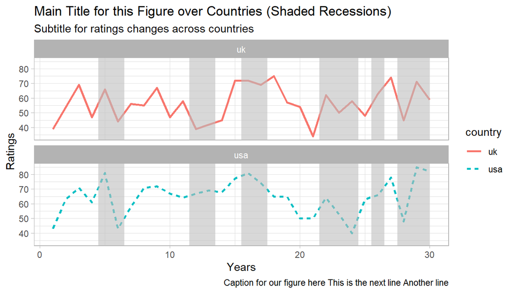

```r
# basic chart with two lines
pl_lines_basic <- ggplot() +
    geom_line(data = df_gdp, aes(
        x = year, y = gdp,
        color = country, linetype = country
    ), size = 1) +
    geom_rect(data = df_recession %>%
        filter(window == "w2"), aes(
        xmin = year_start, xmax = year_end,
        ymin = -Inf, ymax = Inf
    ), alpha = 0.6, fill = "gray") +
    labs(
        x = paste0("Years"),
        y = paste0("Ratings"),
        title = paste(
            "Main Title for this Figure over Countries (Shaded Recessions)",
            sep = " "
        ),
        subtitle = paste(
            "Subtitle for ratings changes across",
            "countries",
            sep = " "
        ),
        caption = paste(
            "Caption for our figure here ",
            "This is the next line ",
            "Another line",
            sep = ""
        )
    ) +
    theme_light() +
    facet_wrap(~country, ncol = 1)

# print figure
print(pl_lines_basic)
```

Sixth, we generate a more customized visualization with customized: (1) colors and shapes for lines as well as for windows; (2) x- and y-axis limits, labels, and breaks; (3) customized legend position.

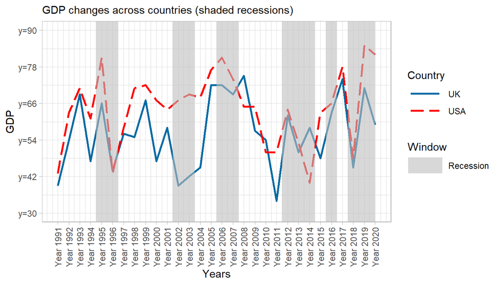

```r
# Window color
st_win_leg_title <- "Window"
st_win_color <- "gray"
st_win_label <- "Recession"
# basic chart with two lines
pl_lines <- ggplot() +
    geom_line(data = df_gdp, aes(
        x = year, y = gdp,
        color = country, linetype = country
    ), size = 1) +
    geom_rect(data = df_recession %>%
        filter(window == "w2"), aes(
        xmin = year_start, xmax = year_end,
        ymin = -Inf, ymax = Inf,
        fill = st_win_color
    ), alpha = 0.6) +
    theme_light()

# Titles
st_x <- "Years"
st_y <- "GDP"
st_subtitle <- "GDP changes across countries (shaded recessions)"
pl_lines <- pl_lines +
    labs(
        x = st_x,
        y = st_y,
        subtitle = st_subtitle
    )

# Figure improvements
# set shapes and colors
st_line_leg_title <- "Country"
ar_st_labels <- c(
    bquote("UK"),
    bquote("USA")
)

ar_st_colours <- c("#026aa3", "red")
ar_st_linetypes <- c("solid", "longdash")
pl_lines <- pl_lines +
    scale_colour_manual(values = ar_st_colours, labels = ar_st_labels) +
    scale_shape_discrete(labels = ar_st_labels) +
    scale_linetype_manual(values = ar_st_linetypes, labels = ar_st_labels) +
    scale_fill_manual(values = c(st_win_color), labels = c(st_win_label)) +
    labs(
        fill = st_win_leg_title,
        colour = st_line_leg_title, linetype = st_line_leg_title
    ) +
    theme(legend.key.width = unit(2.5, "line"))

# Axis
x_breaks <- seq(1, 30, length.out = 30)
x_labels <- paste0("Year ", x_breaks + 1990)

x_min <- 1
x_max <- 30

y_breaks <- seq(30, 90, length.out = 6)
y_labels <- paste0("y=", y_breaks)
y_min <- 30
y_max <- 90

pl_lines <- pl_lines +
    scale_x_continuous(
        labels = x_labels, breaks = x_breaks,
        limits = c(x_min, x_max)
    ) +
    theme(axis.text.x = element_text(
        # Adjust x-label angle
        angle = 90,
        # Adjust x-label distance to x-axis (up vs down)
        hjust = 0.4,
        # Adjust x-label left vs right wwith respect ot break point
        vjust = 0.5
    )) +
    scale_y_continuous(
        labels = y_labels, breaks = y_breaks,
        limits = c(y_min, y_max)
    )

# print figure
print(pl_lines)
```

Finally, we generate a figure with three fill colors for the three windows, main, backward, and forward windows. We reuse various parameters used in the prior block.

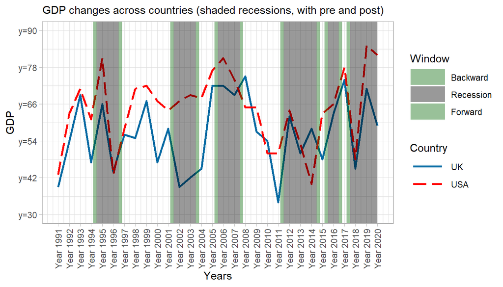

```r
# Window color
st_win_leg_title <- "Window"
# basic chart with two lines
pl_lines <- ggplot() +
    geom_line(data = df_gdp, aes(
        x = year, y = gdp,
        color = country, linetype = country
    ), size = 1) +
    geom_rect(data = df_recession, aes(
        xmin = year_start, xmax = year_end,
        ymin = -Inf, ymax = Inf,
        fill = window
    ), alpha = 0.4) +
    theme_light()

# Titles
st_x <- "Years"
st_y <- "GDP"
st_subtitle <- "GDP changes across countries (shaded recessions, with pre and post)"
pl_lines <- pl_lines +
    labs(
        x = st_x,
        y = st_y,
        subtitle = st_subtitle
    )

# Figure improvements
# fill label and colors
ar_st_win_color <- c("darkgreen", "black", "darkgreen")
ar_st_win_label <- c("Backward", "Recession", "Forward")
# set shapes and colors
st_line_leg_title <- "Country"
ar_st_labels <- c(
    bquote("UK"),
    bquote("USA")
)

ar_st_colours <- c("#026aa3", "red")
ar_st_linetypes <- c("solid", "longdash")
pl_lines <- pl_lines +
    scale_colour_manual(values = ar_st_colours, labels = ar_st_labels) +
    scale_shape_discrete(labels = ar_st_labels) +
    scale_linetype_manual(values = ar_st_linetypes, labels = ar_st_labels) +
    scale_fill_manual(values = c(ar_st_win_color), labels = c(ar_st_win_label)) +
    labs(
        fill = st_win_leg_title,
        colour = st_line_leg_title, linetype = st_line_leg_title
    ) +
    theme(legend.key.width = unit(2.5, "line"))

# Axis
x_breaks <- seq(1, 30, length.out = 30)
x_labels <- paste0("Year ", x_breaks + 1990)

x_min <- 1
x_max <- 30

y_breaks <- seq(30, 90, length.out = 6)
y_labels <- paste0("y=", y_breaks)
y_min <- 30
y_max <- 90

pl_lines <- pl_lines +
    scale_x_continuous(
        labels = x_labels, breaks = x_breaks,
        limits = c(x_min, x_max)
    ) +
    theme(axis.text.x = element_text(
        # Adjust x-label angle
        angle = 90,
        # Adjust x-label distance to x-axis (up vs down)
        hjust = 0.4,
        # Adjust x-label left vs right wwith respect ot break point
        vjust = 0.5
    )) +
    scale_y_continuous(
        labels = y_labels, breaks = y_breaks,
        limits = c(y_min, y_max)
    )

# print figure
print(pl_lines)
```